# Analysis on Mueller Report in Twitter

Group 12: Ningyan Mao, Yunjia Jiang, Longsheng Yin

[figure not shown]

## Part1: Introduction

The Special Counsel investigation was an investigation of Russian interference in the 2016 United States elections and suspicious links between Trump associates and Russian officials, conducted by special prosecutor Robert Mueller from May 2017 to March 2019. It was also called the Russia investigation, the Mueller probe, and the Mueller investigation *(Panetta, Grace (January 23, 2019))*. The Special Counsel's office concluded its investigation and submitted the final report to Attorney General William Barr on March 22, 2019. The release of the Mueller Report causes a hot discussion on Twitter.

We grabbed the data from twitter API and store the data into our MySQL database after creating a table in it. Our raw data set includes 2,683,444 records and eight columns: Index, Post_Id, Post, Time, User_Id, Location, Followers and Retweeter_Id. Detailed information about data set please see the following section.

We started to collect the data about this report at 12 PM on March 23, 2019, to view the spread of this event on social network and try to find:

- **How does the discussion spread from the time and location dimensions?**
- **Who is the most influential person in this discussion?**
- **What are the most common hashtags and posts in this discussion?**
- **What's people's attitude towards it?**

## Part 2: Data Preparation

### Step 1 : Import modules

```python
from tweepy import Stream
from tweepy import OAuthHandler
from tweepy.streaming import StreamListener
import MySQLdb

import time
import json
import mysql.connector
from mysql.connector import Error

import pandas as pd
import datetime as dt
import numpy as np
import networkx as nx
pd.options.mode.chained_assignment = None

from copy import deepcopy
from string import punctuation

from nltk.tokenize import MWETokenizer
import gensim
from gensim.models.word2vec import Word2Vec
LabeledSentence = gensim.models.doc2vec.LabeledSentence

import re
import nltk
import seaborn as sns

from gensim.corpora.dictionary import Dictionary
from gensim.models.tfidfmodel import TfidfModel

import string, itertools
from collections import Counter, defaultdict

import warnings
warnings.filterwarnings('ignore')

import geopandas as gpd
from shapely.geometry import Point, Polygon
import matplotlib.pyplot as plt
import pandas as pd
%matplotlib inline
from shapely.geometry import Point
import adjustText as aT

import pyLDAvis.gensim

import string, itertools
from collections import Counter, defaultdict

from wordcloud import WordCloud, STOPWORDS, ImageColorGenerator
import matplotlib.pyplot as plt
```

### Step 2 : Grab Data

We grabbed the data we need from twitter API and store the data into our MySQL database after creating a table in it. By doing so, we got over two million records of tweets about Mueller report within 24 hours.

#### 1. Create a table in MySQL.

CREATE TABLE `tweets` (

`id` int(11) NOT NULL AUTO_INCREMENT,

`post_id` varchar(30) DEFAULT NULL,

`text` text,

`date` varchar(50) DEFAULT NULL,

`user_id` varchar(30) DEFAULT NULL,

`location` varchar(500) DEFAULT NULL,

`follwers` int(11) DEFAULT NULL,

`retwitter_id` varchar(30) DEFAULT NULL,  
PRIMARY KEY (`id`)  
) ENGINE=InnoDB AUTO_INCREMENT=2578314 DEFAULT CHARSET=utf8mb4;

#### 2. Connect to twitter API `'Tweepy'` to grap data and store data into the database.

```python
# set up connection to db
# make sure to set charset to 'utf8mb4' to support emoji
conn = MySQLdb.connect(host= "localhost",
                  user="root",
                  passwd="ningyan",
                  db="metoo",
                  charset = 'utf8mb4')
cursor=conn.cursor()

#Twitter consumer key, consumer secret, access token, access secret
ckey="Ni5EsXDFkvzf92q9MXou5JvBr"
csecret="eXmnMJFK17WLyPnCIO7Ot2dtkhSmm15KLGIULPOWPjvg8RDFLC"
atoken="1108460762165661698-b8sECsjbXamAhAF0pytDTNL1WxyTS9"
asecret="uOOJhqmBslBNObdbHzpVDaopn6gzKhYN0wVDiMX8oL3Is"

# set up stream listener
class listener(StreamListener):

    def on_data(self, data):
        all_data = json.loads(data)
# collect all desired data fields
        if 'text' in all_data:
            post_id = all_data['id_str']
            text = all_data['text']
            date = all_data['created_at']
            user_id = all_data['user']['id_str']
            follwers = all_data['user']['followers_count']
            if all_data["user"]["location"] is None:
                location='NULL'
            else:
                location= all_data["user"]["location"]
            if 'retweeted_status' in all_data:
                retwitter_id=all_data["retweeted_status"]['user']['id_str']
            else:
                retwitter_id= 'NULL'
# insert values into the db
            cursor.execute('INSERT INTO tweets(post_id,text,date,user_id,location,followers,retwitter_id) VALUES (%s,%s,%s,%s,%s,%s,%s)',(post_id,text,date,user_id,location,follwers,retwitter_id))
            conn.commit()
            return True
        else:
            return True

    def on_error(self, status):
        print(status)

auth = OAuthHandler(ckey, csecret)
auth.set_access_token(atoken, asecret)

# create stream and filter on a searchterm
twitterStream = Stream(auth, listener())
twitterStream.filter(track=['mueller','report','trump','donald'], languages = ["en"], stall_warnings = True)

#stop after 24 hours
```

### Step 2 ：Data Preprocessing

#### 1. Load Data

Load data from MySQL to .csv file called 'tweetsdata.csv'.

```python
try:
    mySQLconnection = mysql.connector.connect(host='localhost',
                             database='metoo',
                             user='root',
                             password='ningyan')
    sql_select_Query = "select * from tweets"
    cursor = mySQLconnection .cursor()
    cursor.execute(sql_select_Query)
    records = cursor.fetchall()
    data=pd.DataFrame(records)
except Error as e :
    print ("Error while connecting to MySQL", e)
finally:
    #closing database connection.
    if(mySQLconnection .is_connected()):
        mySQLconnection.close()
        print("MySQL connection is closed")

# save the dataframe into .csv file
data.to_csv('tweetsdata.csv')
```

```
MySQL connection is closed
```

```python
data=pd.read_csv('tweetsdata.csv',index_col=False,dtype={'Post_Id':str,'User_Id':str,'Retweeter_Id':str})
data.columns=['Index','Post_Id','Post','Time','User_Id','Location','Followers','Retweeter_Id']
```

#### 2. Data Description

- **Index**: auto-increment index for each record in our dataset.
- **Post_Id**: the id for each tweet.
- **Post**: the content for each tweet.
- **Time**: Greenwich Mean Time (GMT) and date of each tweet.
- **User_Id**: id of the user who posts that tweet.
- **Location**: the location of the user when posting the tweet.
- **Followers**: number of followers for the user who posts the tweet.
- **Retweeter_Id**: id of the user of the original post (null if it is not retweeted).

#### 3. Data Glimpse

```python
data.shape
```

```
(2683444, 8)
```

```python
data.head()
```

|  | Index | Post_Id | Post | Time | User_Id | Location | Followers | Retweeter_Id |
| --- | --- | --- | --- | --- | --- | --- | --- | --- |
| 0 | 0 | 1109480622697832454 | RT @JamilSmith: There was another important re... | Sat Mar 23 15:42:48 +0000 2019 | 831129801402376194 | NaN | 28.0 | NaN |
| 1 | 1 | 1109480622827855872 | RT @SethAbramson: 29/ But Mueller did somethin... | Sat Mar 23 15:42:48 +0000 2019 | 189942191 | NaN | 846.0 | NaN |
| 2 | 2 | 1109480623104843779 | RT @JackPosobiec: Listen to John Brennan’s las... | Sat Mar 23 15:42:48 +0000 2019 | 3320941218 | Alabama Backup account @mk55rk | 11449.0 | NaN |
| 3 | 3 | 1109480623276806145 | RT @EliLake: It’s a big deal if Mueller does o... | Sat Mar 23 15:42:48 +0000 2019 | 2457271032 | On Patreon & SubscribeStar. Bergoglio is an An... | 2390.0 | NaN |
| 4 | 4 | 1109480622991433729 | RT @mitchellvii: Conspiracy Theorist Rachel Ma... | Sat Mar 23 15:42:48 +0000 2019 | 388077359 | NaN | 4162.0 | NaN |

#### *Problems*

- **'Index'**：This column is unnecessary for our following analysis.
- **'Post'**：This column has a lot of messy values which cannot be applied by our analysis directly.
- **'Time'**：The format of this column is not the ideal one for our analysis.
- **'Location'**：This column has a lot of messy values which cannot be applied by our analysis directly and also has plenty of empty values.
- **'Followers'**：This column has some empty values and be treated as categorical variable rather than integer.
- **'Retweeter_Id'**：This column has a lot of empty values.

#### 4. Clean data

#### * Clean the values of features

- **'Index'**：Drop the whole column.

```python
data=data.drop(['Index'],axis=1)
```

- **'Post'**：Extract `hashtages` and `contents` from the text basing on the requirments of analysis.

```python
regex_str = r"(?:\#+[\w_]+[\w\'_\-]*[\w_]+)" # hash-tags

tokens_re = re.compile(r'('+regex_str+')', re.VERBOSE | re.IGNORECASE)

def tokenize(s):
    s=str(s)
    return tokens_re.findall(s)
```

```python
data['Hashtags'] = data['Post'].map(tokenize)
```

```python
def clean_tweet(tweet):
    tweet = re.sub(r'http\S+', '', tweet)
    tweet = re.sub(r"#(\w+)", '', tweet)
    tweet = re.sub(r"@(\w+)", '', tweet)
    tweet = re.sub(r'[^\w\s\']', '', tweet)
    tweet = re.sub(r'[0-9]', '', tweet)
    tweet = re.sub(r'RT', '', tweet)
    tweet = tweet.strip().lower()
    return tweet
```

```python
data['Post'] = data['Post'].astype(str).map(clean_tweet)
```

- **'Time'**：Convert the strings into datetime values.

```python
day=data.Time.str.split(' ').str[2]

hour=data.Time.str.split(' ').str[3].str.split(':').str[0]
minute=data.Time.str.split(' ').str[3].str.split(':').str[1]
second=data.Time.str.split(' ').str[3].str.split(':').str[2]
time=pd.concat([day,hour,minute,second], axis=1)

data['Time'] = time.apply(
    lambda x: '-'.join(x.astype(str)),
    axis=1
)
```

```python
# there is several wrongly recorded data whose time value is NaN
data.drop(data[data['Time']=='nan-nan-nan-nan'].index,axis=0,inplace=True)
data.drop(data[data['Time']=='is-the-nan-nan'].index,axis=0,inplace=True)
data=data.reset_index(drop=True)
```

```python
data['Time']=data['Time'].apply(lambda x: dt.datetime.strptime(x, '%d-%H-%M-%S'))
data['Time'] = data['Time'].map(lambda t: dt.datetime(year=2019, month=3, day=t.day, hour=t.hour, minute=t.minute ,second=t.second))
```

- **'Location'**：Fliter out meanless values of this column; Unify the levels of geographic locations to `states`.

```python
data['Location'] = data.Location.str.split(',').str[-1].str.lower()
```

```python
# get a list of states and a list of avvreviated states in the USA from URL
locations = pd.read_html('http://www.softschools.com/social_studies/state_abbreviations/',header=0)[2]
states = locations['State'].str.lower().tolist()
states_a = locations['Abbreviation'].str.lower().tolist()
```

```python
# get a dataframe showing the state abbreviation of cities from URL
locations1 = pd.read_html('https://events.mapchannels.com/Cities.aspx',header=0)[3]
locations1 = locations1[locations1['Unnamed: 2']=='United States'].iloc[:,:2]
locations1.columns = ['Location','States_abb']
# get a list of all city names in the USA
cities = locations1.iloc[:,0].str.lower().tolist()
```

```python
# create 3 dataframes whose 'Location' are city-name, state-name and state-avvreviation, respectively
data_cities = data[data['Location'].str.strip().isin(cities)]
data_states = data[data['Location'].str.strip().isin(states)]
data_states_a = data[data['Location'].str.strip().isin(states_a)]
```

```python
# convert locations1 into lower case
for i in locations1.columns:
    locations1[i]=locations1[i].str.lower()
```

```python
# use .merge() to add a new column, 'States_abb', to data_cities
data_cities1 = data_cities.merge(locations1,on = 'Location')
data_cities1 = data_cities1[['Post_Id','States_abb']]
```

```python
# convert locations into lower case
for i in locations.columns:
    locations[i] = locations[i].str.lower()
locations.columns = ['Location','States_abb']
```

```python
# use .merge() to add a new column, 'States_abb', to data_states
data_states1 = data_states.merge(locations,on = 'Location')
data_states1 = data_states1[['Post_Id','States_abb']]
```

```python
# choose and rename columns from data_states_a
data_states_a1 = data_states_a[['Post_Id','Location']]
data_states_a1.columns = ['Post_Id','States_abb']
```

```python
# create a new dataframe by combining data_cities1, data_states1, and data_states_a1
data_states = pd.concat([data_cities1,data_states1,data_states_a1], axis=0, sort=False).reset_index()
data_states['States_abb'] = data_states['States_abb'].str.upper()
data_states=data_states.drop(['index'],axis=1)
```

```python
data=pd.merge(data,data_states,on=['Post_Id'],how='left')
data['Location']=data['States_abb']
data.drop(['States_abb'],axis=1,inplace=True)
```

- **'Followers'**：Fill `integer 0` into empty values; Convert the type of this column from `string` to `integer`.

```python
data['Followers']=data['Followers'].fillna(0).astype(int)
```

##### Have a glimpse of cleaned data

```python
data.head(10)
```

|  | Post_Id | Post | Time | User_Id | Location | Followers | Retweeter_Id | Hashtags |
| --- | --- | --- | --- | --- | --- | --- | --- | --- |
| 0 | 1109480622697832454 | there was another important report released to... | 2019-03-23 15:42:48 | 831129801402376194 | NaN | 28 | NaN | [] |
| 1 | 1109480622827855872 | but mueller did something else for america tha... | 2019-03-23 15:42:48 | 189942191 | NaN | 846 | NaN | [] |
| 2 | 1109480623104843779 | listen to john brennans last interview talking... | 2019-03-23 15:42:48 | 3320941218 | NaN | 11449 | NaN | [] |
| 3 | 1109480623276806145 | its a big deal if mueller does or doesnt find ... | 2019-03-23 15:42:48 | 2457271032 | NaN | 2390 | NaN | [] |
| 4 | 1109480622991433729 | conspiracy theorist rachel maddow cries on air... | 2019-03-23 15:42:48 | 388077359 | NaN | 4162 | NaN | [] |
| 5 | 1109480623243255808 | history of american people being told to move ... | 2019-03-23 15:42:48 | 14678371 | TX | 213 | NaN | [] |
| 6 | 1109480623247261696 | mueller report has been delivered on the th an... | 2019-03-23 15:42:48 | 26046318 | OR | 3855 | NaN | [] |
| 7 | 1109480623373049857 | the fbi was with her\nthe cia was with her\nth... | 2019-03-23 15:42:48 | 917107876799299584 | NaN | 4191 | NaN | [] |
| 8 | 1109480623230468101 | wouldnt it be wild if muellers report showed t... | 2019-03-23 15:42:48 | 992399150833483779 | NaN | 200 | NaN | [] |
| 9 | 1109480623440359425 | we pay attn to facts where exactly has he been... | 2019-03-23 15:42:48 | 936838388749099009 | NaN | 4860 | NaN | [] |

#### * Create different data sets for different analysis purposes.

- **'data_location'**: Filter out the rows whose 'Location' column is empty.

```python
data_location=data[data['Location'].isnull()==False].reset_index(drop=True)
```

```python
data_location.head()
```

|  | Post_Id | Post | Time | User_Id | Location | Followers | Retweeter_Id | Hashtags |
| --- | --- | --- | --- | --- | --- | --- | --- | --- |
| 0 | 1109480623243255808 | history of american people being told to move ... | 2019-03-23 15:42:48 | 14678371 | TX | 213 | NaN | [] |
| 1 | 1109480623247261696 | mueller report has been delivered on the th an... | 2019-03-23 15:42:48 | 26046318 | OR | 3855 | NaN | [] |
| 2 | 1109480623163535362 | says trump supporters should wait to celebrate... | 2019-03-23 15:42:48 | 518716206 | MA | 2169 | NaN | [] |
| 3 | 1109480624035749893 | a symptom of our whackedout times the nonstop ... | 2019-03-23 15:42:48 | 818936673559932928 | CA | 178 | NaN | [] |
| 4 | 1109480625008988160 | we don't know what the mueller report says but... | 2019-03-23 15:42:48 | 75877857 | TX | 1059 | NaN | [] |

```python
data_location.shape
```

```
(516410, 8)
```

- **'data_retweet'**: Filter out the rows whose 'Location' and 'Retweeter_Id' columns are empty .

```python
data_retweet=data_location[data_location['Retweeter_Id'].isnull()==False].set_index(['Post_Id'])
```

```python
data_retweet.head()
```

| Post_Id | Post | Time | User_Id | Location | Followers | Retweeter_Id | Hashtags |
| --- | --- | --- | --- | --- | --- | --- | --- |
| 1109485573453025280 | this is the biggest takeaway from the mueller ... | 2019-03-23 16:02:28 | 1690852645 | GA | 761 | 232901331 | [] |
| 1109485574052872192 | hey adam schiff\n\nyou said you had direct evi... | 2019-03-23 16:02:28 | 157063397 | MI | 31 | 292929271 | [] |
| 1109485574933676032 | release the report\nrelease the report\nreleas... | 2019-03-23 16:02:28 | 1084576257717743617 | OH | 608 | 377609596 | [] |
| 1109485574728155136 | this held up well | 2019-03-23 16:02:28 | 27164836 | TX | 29 | 112047805 | [] |
| 1109485575038484481 | ironic that the same media lunatics claiming t... | 2019-03-23 16:02:28 | 2225978269 | NY | 217 | 232901331 | [] |

```python
data_retweet.shape
```

```
(394399, 7)
```

- **data_retweet1**:Filter out the row whose 'Retweeter_Id' columns are empty .

```python
data_retweet1=data[data['Retweeter_Id'].isnull()==False]
data_retweet1=data_retweet1.loc[:,['User_Id','Retweeter_Id','Followers']].reset_index(drop=True)
```

```python
data_retweet1.head()
```

|  | User_Id | Retweeter_Id | Followers |
| --- | --- | --- | --- |
| 0 | 1690852645 | 232901331 | 761 |
| 1 | 785279237875961856 | 800111181058838528 | 1092 |
| 2 | 896424188 | 139823781 | 249 |
| 3 | 1060913826063937537 | 558294779 | 3551 |
| 4 | 274238350 | 550250082 | 107 |

```python
data_retweet1.shape
```

```
(2004810, 3)
```

## Part 3: Data Analysis

### 1. The overall pattern of the spread of `The release of Muller Report` in Twitter.

#### * Volume

**(1) How does the volume of posts related to this event develop in Twitter by time series?**

The volume of posts related to 'Muller Report' developed by the time series.

```python
date_time=data.set_index('Time')
```

```python
# plot the post volumn between 17:00 on Mar 23th to 15:30 on Mar 24th
date_time=date_time['Post_Id'].resample('15Min').size().to_frame()
date_time['mean']=date_time['Post_Id'].mean()
```

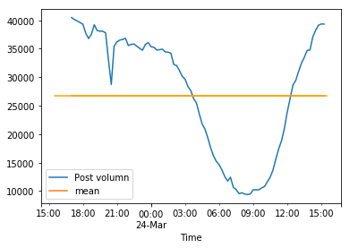

```python
# plot the post volumn between 17:00 on Mar 23th to 15:30 on Mar 24th
date_time.loc['2019-03-23 17:00:00':'2019-03-24 15:15:00'].plot()
date_time['mean'].plot(color='orange')
plt.legend(('Post volumn','mean'))
```

According to this plot, we find out that the number of posts is relatively low from 3:00 to 12:00 GMT, which is from 23:00 to 8:00 in the US. It is because most people were sleeping.  
Except for this, the heat of this event remained high during these 24 hours.

We try to analyze, during this event, which states in United States behaved most actively.

```python
# create a new dataframe, data_location1, to show the number of tweets posted in each state
data_location1=data_location.groupby('Location').size().sort_values(ascending=False).to_frame().reset_index()
data_location1.columns=['STATE_ABBR','POST_NUM']
data_location1.head()
```

|  | STATE_ABBR | POST_NUM |
| --- | --- | --- |
| 0 | CA | 54050 |
| 1 | TX | 32970 |
| 2 | NY | 31549 |
| 3 | FL | 29012 |
| 4 | CA | 17555 |

```python
usa=gpd.read_file('states_21basic')
usa1=usa[['STATE_ABBR','geometry']]
```

```python
merged=usa.merge(data_location1,on='STATE_ABBR')
```

```python
colors = 10
cmap = 'GnBu'
figsize = (20, 10)
post_num = 'POST_NUM'
cols = ['STATE_NAME', 'STATE_ABBR', post_num]
merged['center']=merged['geometry'].centroid
points=merged.copy()
points.set_geometry("center", inplace = True)
labeles=zip(points['STATE_ABBR'],points.geometry)
```

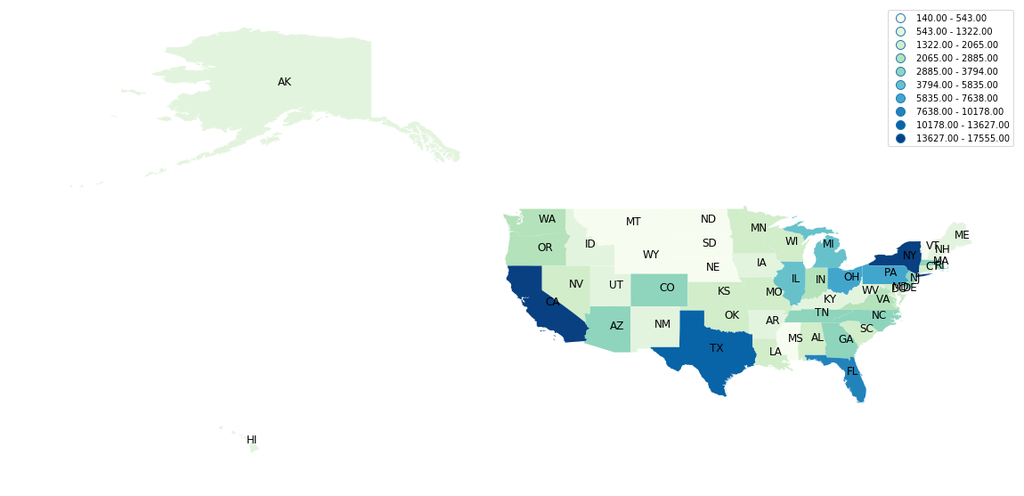

```python
ax = merged.plot(column=post_num, cmap=cmap, figsize=figsize,label='STATE_ABBR', scheme='fisher_jenks', k=colors,legend=True)
ax.set_axis_off()
fig = plt.gcf()
fig.set_size_inches(20, 10)
for i, geo in labeles:
    ax.annotate(s=i, xy=[geo.x, geo.y], color="black",fontsize=12)
ax.get_legend().set_bbox_to_anchor((1, 1))
```

##### _Population by state_

[figure not shown]

Furthermore, we try to divide the posts frequency for each state by its population.

```python
population=pd.read_html('https://simple.wikipedia.org/wiki/List_of_U.S._states_by_population')[0]
population1=population.iloc[1:53,2:4]
population1.drop(30,axis=0,inplace=True)
population1.columns=['STATE_NAME','population']
merged1=merged.merge(population1,on='STATE_NAME')
merged1['population']=merged1['population'].astype(int)
merged1['post_rate']=merged1['POST_NUM']/merged1['population']*1000
```

```python
colors = 10
cmap = 'GnBu'
figsize = (20, 10)
post_rate = 'post_rate'
cols = ['STATE_NAME', 'STATE_ABBR', post_rate]
merged1['center']=merged1['geometry'].centroid
points=merged1.copy()
points.set_geometry("center", inplace = True)
labeles=zip(points['STATE_ABBR'],points.geometry)
```

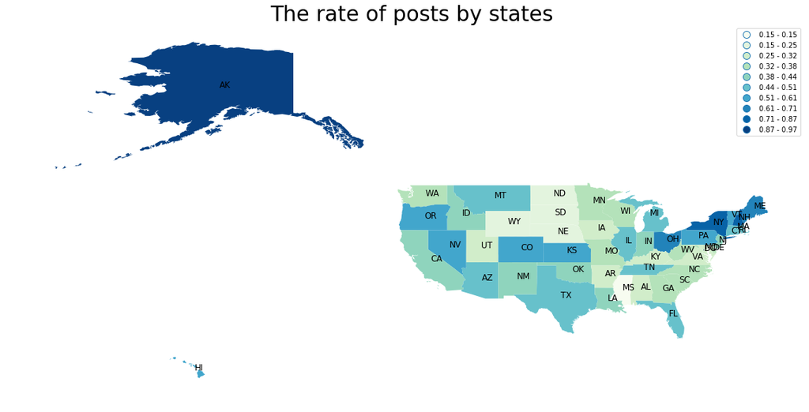

```python
ax = merged1.plot(column=post_rate, cmap=cmap, figsize=figsize,label='STATE_ABBR', scheme='fisher_jenks', k=colors,legend=True)
ax.set_axis_off()
ax.set_title('The rate of posts by states',fontsize=30)
fig = plt.gcf()
fig.set_size_inches(20, 10)
for i, geo in labeles:
    ax.annotate(s=i, xy=[geo.x, geo.y], color="black",fontsize=12)
ax.get_legend().set_bbox_to_anchor((1, 1))
```

After the frequency divided by population, we can see that California, which with the highest total tweet frequency, does not remain same high rank as previous. While the most states located on the east and west coast still rank on the top.

**(3) Is there any relationships between time and location in terms of the distribution of posts volume?**

After visualizing the distribution of number of posts by time and by location, we want to find out the relationship between time and location by using heatmap. We use data_location dataframe, which only contains records whose locations are in the U.S.

```python
# drop some records outside our time analysis range from data_location
data_location['Hour']=data_location['Time'].map(lambda x: str(x.hour))
data_location2=data_location.drop(data_location[data_location['Hour']=='15'].index).drop(data_location[data_location['Hour']=='16'].index)
```

```python
# select top 10 states with most number of posts
data_location2['Location']=data_location2['Location'].str.strip()
top_states=data_location2.groupby('Location').size().sort_values(ascending=False).head(10).to_frame().reset_index()
top_states=top_states['Location'].tolist()
data_location2=data_location2.loc[data_location2['Location'].isin(top_states)]
```

```python
top_states
```

```
['CA', 'NY', 'TX', 'FL', 'PA', 'IL', 'OH', 'AZ', 'WA', 'NC']
```

```python
data_time_loc=data_location2.pivot_table(index='Location',columns='Hour',values='Post',aggfunc='count')
column_order = ['17', '18', '19','20','21', '22', '23','0', '1', '2', '3', '4', '5', '6', '7', '8', '9', '10', '11', '12', '13', '14',]
data_time_loc = data_time_loc.reindex_axis(column_order, axis=1).reindex_axis(top_states,axis=0)
```

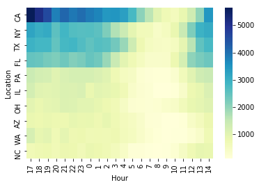

```python
#plt.figure(figsize = (10,10))
sns.heatmap(data_time_loc,cmap='YlGnBu')
plt.show()
```

According to this heatmap, we find out that, in CA, people posted tweets immidiately when the event happened,then the heat declined during the following hours, while in NY, people paid more attention on this event after several hours,and still tallked about it a lot on the next day morning. Reasons behind it can be the character differences.

#### * Retweet Network

**(1) How do the users who contributed to the spread of this event connect to each other?**

Analyze the retweet network by the relation between original posts and retweeted posts.

```python
# Draw network between tweeters and retweeters
G=nx.from_pandas_edgelist(data_retweet1,'Retweeter_Id','User_Id',edge_attr='Followers')
nx.write_gexf(G, "location.gexf")
```

Because of the large volume of data, Networx cannot visualize data appropriately, while Gephi have the ability to display a file, which includes the large volume of data, generated by networkx.

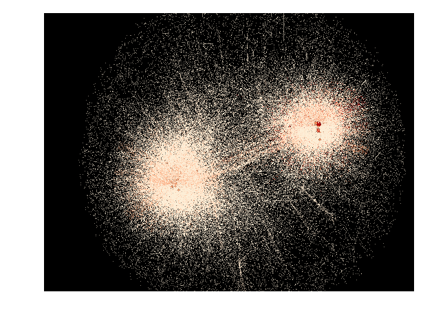

```python
img=plt.imread('retweet_network.png')
plt.axis('off')
fig = plt.gcf()
fig.set_size_inches(12, 8)
plt.imshow(img)
plt.show()
```

- This graph shows us the distribution of the whole network and the two main nodes are the posters whose posts were most frequently retweeted.
- The whole retweet network during this event can be divided into two parts, which means the retweet network includes two small main networks. However, there are also some connections between these two groups. Most of these connections are output by the main nodes in each group.
- Base on this, an intersting pattern of the retweet network is found that users indentified into different group seldom retweeted the post of users belong to the other group, except main nodes.
- In the following sections, we will do more content analysis about these two hubs and sentiment analysis about these two clusters.

```python
data_retweet1.groupby('Retweeter_Id').size().sort_values(ascending=False)[:10]
```

```
Retweeter_Id
292929271     50794
78523300      41167
232901331     25218
3223426134    21926
2421067430    19901
963480595     19136
133938408     18610
219617448     16368
14247236      15892
592730371     15651
dtype: int64
```

```python
data_retweet1.groupby('User_Id')['Followers'].max().sort_values(ascending=False)[:10]
```

```
User_Id
428333       54928581
807095       43101647
28785486     14210863
95023423     14008754
51241574     13235131
37034483     11325472
207809313    10772821
130104041     8944210
5392522       7715506
265902729     7712670
Name: Followers, dtype: int32
```

Without the overlap between the most popular users in the network and the users who have the most popular tweets, an obevious relationship between the number of retweets and the number of followers cannot be found during this event.  
Thus, the popularity of post is not only decided by the follower of this user but also influenced by the content of these posts.

### 2. Analyze key words of posts by Hashtag.

**(1) What are the most common Hashtags during the event spread ?**

```python
tags = []
b = data_location['Hashtags'].tolist()
for singlelist in b:
    for element in singlelist:
        m = re.search('#\w+', element)
        if m is not None:
            tags.append(m.group())
```

```python
tags_new = pd.DataFrame(tags)
tags_new.columns = ['Tags']
tags_new = tags_new.groupby(by=['Tags']).size().sort_values(ascending=False)
```

```python
# draw the word cloud for tags
tags_new = str(tags_new)
wordcloud = WordCloud(stopwords=STOPWORDS,
                      background_color='white',
                      width=2000,
                      height=1500
                      ).generate(tags_new)
```

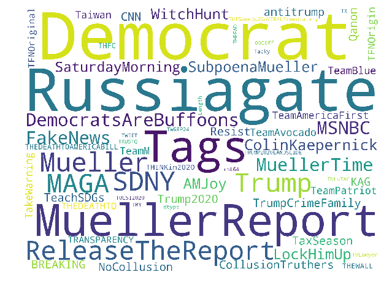

```python
plt.axis('off')
fig = plt.gcf()
fig.set_size_inches(12, 8)
plt.imshow(wordcloud)
plt.show()
```

**(2) How does the frequency of Hashtags change by location?**

```python
data_new=data_location.loc[:,['Post_Id','User_Id','Followers','Retweeter_Id','Location','Hashtags']].set_index('Post_Id')
```

```python
data_new['Hashtags'] = data_new['Hashtags'].where(data_new['Hashtags'].str.len() > 0, np.nan)
data_tags = data_new[data_new.Hashtags.notnull()]
```

```python
data_states = data_tags.groupby(['Location']).count()
data_states = pd.DataFrame(data_states['Hashtags'])
data_states.reset_index(level=0, inplace=True)
data_states['location'] = data_states['Location']
data_states.set_index('location').sort_values(by=['Hashtags'],ascending=False).head(5)
```

| location | Location | Hashtags |
| --- | --- | --- |
| CA | CA | 4439 |
| TX | TX | 2648 |
| FL | FL | 2648 |
| NY | NY | 2561 |
| CA | CA | 1547 |

```
<BarContainer object of 183 artists>
```

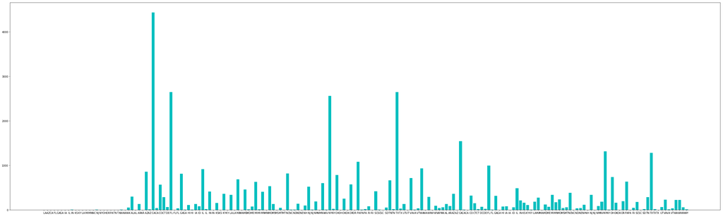

```python
plt.figure(figsize=(50, 15))
plt.bar(x=data_states['location'], height=data_states['Hashtags'], color='c')
```

- From the above plot, we can see that CA, NY, FL, TX have tremendous high amount of hashtags compared to other states.
- In accordance with the map in the Geography Analysis section, these four states are the top four states with highest posting frequency.
- High-frequency users know how to post tweets effectively.

**(3) Is there relationship between hashtags and the influence of the posters?**

```python
data_followers = data_tags.groupby(['Followers']).count()
data_followers = pd.DataFrame(data_followers['Hashtags'])
```

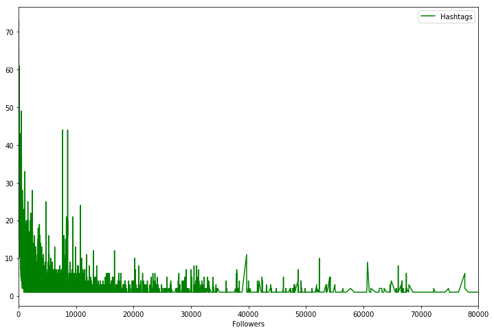

```python
data_followers.plot(figsize=(12,8),color='g')
plt.xlim([0,80000]);
```

Different from what we usually thought that posters with lots of followers tend to apply keywords to guide public opinion, there is no specific relationship between the number of followers and the hashtags applied frequency.

**(4) Is there relationship between hashtags and conversion rate?**

- **Potential reach:** number of followers of the targeted account, which is the value under the column **'Followers'**.
- **Actual reach:** number of retweets received by each post. Create a column : **'Retweets'**.
- **Conversion Rate:** measured by number of actual reach divided by number of potential reach. Create a column : **'Conversion Rate'**. Use it to measure the spread out facilitating of each hashtag.

```python
data_retweeter = data_tags.groupby(['Retweeter_Id']).count()
data_retweeter = pd.DataFrame(data_retweeter['Hashtags'])
```

```python
a = 0
Retweets = []
for j in range(13626):
    for i in range(13626):
        if data_tags['Retweeter_Id'].values[i] == data_tags['User_Id'].values[j]:
            a += 1
    Retweets.append(a)
    a = 0
```

```python
data_tags['Retweets'] = Retweets
data_tags['Conversion Rate'] = data_tags['Retweets'] / data_tags['Followers']
data_tags['Conversion Rate'] = data_tags['Conversion Rate'].apply(lambda x: "{0:.2f}%".format(x*100))
```

```python
data_tags_filtered = data_tags[(data_tags['Conversion Rate'] != '0.00%') & (data_tags['Conversion Rate'] != 'nan%')]
data_tag_rate = data_tags_filtered[['Hashtags', 'Conversion Rate']]
```

```python
data_tag_rate['Conversion Rate'] = data_tag_rate['Conversion Rate'].str.replace('%','').astype(float)/100
```

```python
u = pd.DataFrame(data_tag_rate.groupby(['Hashtags'])['Conversion Rate'].mean())
u.sort_values('Conversion Rate', ascending=False)
```

| Hashtags | Conversion Rate |
| --- | --- |
| ['#Topbuzz'] | 0.026300 |
| ['#Mueller'] | 0.026300 |
| ['#MuellersReport'] | 0.017633 |
| ['#LaraLogan', '#socialmedia', '#BreakingNews', '#news', '#usa', '#TRUMP', '#denver', '#Seattle'] | 0.015000 |
| ['#DEMOCRATS', '#TRUMP', '#NEWS', '#SOCIALMEDIA', '#BREAKINGNEWS', '#LOSANGELES', '#ALBUQUERQUE', '#SANTAFE', '#CH'] | 0.015000 |
| ['#DEMOCRATS', '#TRUMP', '#SOCIALMEDIA', '#NEWS', '#BREAKINGNEWS'] | 0.015000 |
| ['#LaraLogan', '#socialmedia', '#BreakingNews', '#news', '#usa', '#TRUMP', '#denver'] | 0.015000 |
| ['#DEMOCRATS', '#TRUMP', '#NEWS', '#SOCIALMEDIA', '#BREAKINGNEWS', '#LOSANGELES', '#ALBUQUERQUE', '#SANTAFE'] | 0.015000 |
| ['#DEMOCRATS', '#TRUMP', '#SOCIALMEDIA', '#NEWS', '#BREAKINGNEWS', '#PITTS'] | 0.014900 |
| ['#TopMAINEndorser', '#firstdayofspring', '#firstdayofspring2019', '#EmpireFox', '#Cnn'] | 0.011600 |
| ['#peoplesvote'] | 0.009900 |
| ['#RoyCohn', '#Trump'] | 0.005600 |
| ['#Sm'] | 0.005600 |
| ['#FISA702'] | 0.005600 |
| ['#EmolumentsClause', '#Emoluments'] | 0.005600 |
| ['#IndividualOne'] | 0.005600 |
| ['#CindyYang'] | 0.005600 |
| ['#TrumpRussiaDossier', '#Trumps'] | 0.005600 |
| ['#EmolumentsClause', '#TrumpHotelDC'] | 0.005600 |
| ['#RoyCohn'] | 0.005600 |

[figure not shown]

- The hashtag with the highest conversion rate is unexpected. **'#Topbuzz'** is a website for breaking news, usually this official account use its hashtags to attract followers to click, see and reweet their breaking news. Breaking news usually have high converstion rate, when it first spreads out on social platform.
- Ranking behind it are hashtags related with **'#Mueller'** or **'#MuellersReport'**, which are quite the direct topic words for this event.
- After that, hashtags related with **'#Trump'**, the main character of the event, have a higher conversion rate.

### 3. Analyze key words of posts by content.

**(1) What are the most common phrases during the event spread ?**

We used the dataset with location information as a sample of the entire dataset for analyzing.

- Firstly, we tokenized the words from tweets after deleting the links, hashtags, numbers, punctuations and retweet signs.
- Secondly, we added meaningless words and commonly used words into 'english' stopwords and removed them from previously tokenized word lists.
- Thirdly, we lemmatized the words and coverted all the words into a dictionary.
- Finally, we drew a word cloud to show the most frequently used words.

```python
data_post=data_location.drop(['Hashtags','User_Id','Followers'],axis=1)
```

```python
# define a tokenize function to get the words within posts
tokenizer = MWETokenizer()
tokenizer.add_mwe(('white', 'house'))
tokenizer.add_mwe(('american', 'people'))
tokenizer.add_mwe(('hillary', 'clinton'))
tokenizer.add_mwe(('lindsey', 'graham'))

def tokenize(tweet):
    tokens = tokenizer.tokenize(str(tweet).split())
    return tokens
```

```python
data_post['tokens'] = data_post['Post'].map(tokenize)
```

```python
nltk.download('stopwords')
stopword = nltk.corpus.stopwords.words('english')
```

```python
#extend stopwords with meaningless and common words for this case
stopword.extend(['yet','us','here','there','f','n','i\'m','b','he\'s','hes','aren\'t','arent','one','thing','i\'ve','we\'ll','i\'ll','he\'ll','she\'ll','i\'d','she\'d','he\'d','ive','wh','im','\'','dont','would','youre','youve','youll','youd','mightnt','must','mustnt','hed','shed','id','didnt','doesnt','doj','ta','th'])
meaningless_word=['say','said','take','never','still','make','today','know','new','go','going','since','even','ag','amp','get','let','see','two','think','need','like','year','time','day','want','another','done','full','yes','no','sndy','give','seen','ever','may']
stopword.extend(meaningless_word)
common_word=['trump','mueller','muellers','mueller\'s','report','trump\'s','trumps','investigation','president','donald','release']
stopword.extend(common_word)
print(stopword)
```

```
['i', 'me', 'my', 'myself', 'we', 'our', 'ours', 'ourselves', 'you', "you're", "you've", "you'll", "you'd", 'your', 'yours', 'yourself', 'yourselves', 'he', 'him', 'his', 'himself', 'she', "she's", 'her', 'hers', 'herself', 'it', "it's", 'its', 'itself', 'they', 'them', 'their', 'theirs', 'themselve…
```

```python
# remove stop words
def remove_stopwords(text):
    text = [word for word in text if word not in stopword]
    return text

data_post['nonstop'] = data_post['tokens'].apply(lambda x: remove_stopwords(x))
```

```python
# lemmatize the words
nltk.download('wordnet')
wn = nltk.WordNetLemmatizer()

def lemmatizer(text):
    text = [wn.lemmatize(word) for word in text]
    return text

data_post['lemmatized'] = data_post['nonstop'].apply(lambda x: lemmatizer(x))
data_post['lemmatized'] = data_post['lemmatized'].apply(lambda x: remove_stopwords(x))
data_post.drop(['nonstop'],axis=1,inplace=True)
```

```python
data_post.head()
```

|  | Post_Id | Post | Time | Location | Retweeter_Id | Hour | tokens | lemmatized |
| --- | --- | --- | --- | --- | --- | --- | --- | --- |
| 0 | 1109480623243255808 | history of american people being told to move ... | 2019-03-23 15:42:48 | TX | NaN | 15 | [history, of, american_people, being, told, to... | [history, american_people, told, move, without... |
| 1 | 1109480623247261696 | mueller report has been delivered on the th an... | 2019-03-23 15:42:48 | OR | NaN | 15 | [mueller, report, has, been, delivered, on, th... | [delivered, anniversary, secret, watergate, ta... |
| 2 | 1109480623163535362 | says trump supporters should wait to celebrate... | 2019-03-23 15:42:48 | MA | NaN | 15 | [says, trump, supporters, should, wait, to, ce... | [supporter, wait, celebrate, come] |
| 3 | 1109480624035749893 | a symptom of our whackedout times the nonstop ... | 2019-03-23 15:42:48 | CA | NaN | 15 | [a, symptom, of, our, whackedout, times, the, ... | [symptom, whackedout, nonstop, talk, nobody, r... |
| 4 | 1109480625008988160 | we don't know what the mueller report says but... | 2019-03-23 15:42:48 | TX | NaN | 15 | [we, don't, know, what, the, mueller, report, ... | [defended, integrity, independence, special, cou] |

```python
# create a corpus for the lemmatized words
tokenized_corpus = []

for i, tweet in enumerate(data_post['lemmatized']):
    tokenized_corpus.append(tweet)
```

```python
# create a dictionary for the corpus
D = Dictionary(tokenized_corpus)
corpus = [D.doc2bow(report) for report in tokenized_corpus]
```

```python
# Determine total word counts across the entire corpus

# Create the defaultdict: total_word_count
WC = defaultdict(int)
for word_id, word_count in itertools.chain.from_iterable(corpus):
    WC[word_id] += word_count

# Create a sorted list from the defaultdict: sorted_word_count
word_counts = sorted(WC.items(), key=lambda w: w[1], reverse=True)

# Assemble all words with frequencies for Word Cloud
all_words = []
for word_id, word_count in word_counts:
    all_words.extend([D.get(word_id)] * word_count)
```

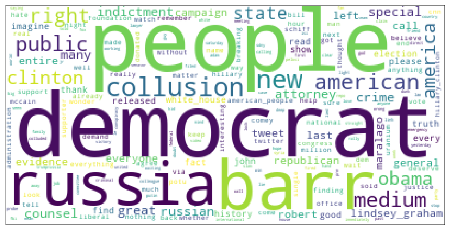

```python
# Word Cloud
wc = WordCloud(background_color='white', collocations=False).generate(' '.join(all_words))
plt.figure(figsize=(18,8))
plt.xticks([])
plt.yticks([])
plt.imshow(wc);
```

According to this word cloud, we can find out that except for common words like 'trump', 'mueller', the most frequently used words are 'democrat', 'people', 'russia' and 'collusion', which indicates that they analyzed this issue from different perspectives and posted their opinions about different topics. We can cluster them into several groups to get these topics.

**(2) What are the most common topics during the event spread ?**

After creating a dictionary for all the words, we built a **TF-IDF** model to convert the content of posts into vectors. Then, we used **LDA** model to divide them into four clusters.Using pyLDAvis module, we can visualize the significant words of each cluster and figure out their topics.

```python
from gensim import corpora, models, similarities
tfidf = models.TfidfModel(corpus)
corpus_tfidf = tfidf[corpus]
```

```python
total_topics = 4
```

```python
lda = models.LdaModel(corpus, id2word=D, num_topics=total_topics)
corpus_lda = lda[corpus_tfidf]
```

```python
lda.show_topics(total_topics,8)
```

```
[(0,
  '0.014*"right" + 0.014*"barr" + 0.008*"many" + 0.007*"special" + 0.007*"without" + 0.006*"back" + 0.006*"public" + 0.006*"counsel"'),
 (1,
  '0.018*"democrat" + 0.015*"medium" + 0.012*"every" + 0.012*"keep" + 0.010*"right" + 0.010*"campaign" + 0.009*"american" + 0.007*"run"'),
 (2,
  '0.022*"collusion" + 0.013*"state" + 0.009*"evidence" + 0.009*"obama" + 0.008*"show" + 0.007*"national" + 0.007*"emergency" + 0.006*"people"'),
 (3,
  '0.011*"lindsey_graham" + 0.010*"good" + 0.010*"russia" + 0.010*"clinton" + 0.009*"great" + 0.009*"news" + 0.009*"america" + 0.009*"everyone"')]
```

```python
lda.save('lda.model')
```

```python
import pyLDAvis.gensim

pyLDAvis.enable_notebook()
panel = pyLDAvis.gensim.prepare(lda, corpus_lda, D, mds='tsne')
panel
```

[interactive chart not shown]

By analyzing the most significant words of each cluster, we can have a general idea of their topics.

- Topic 1: General topic about the event
- Topic 2: Things about democrat
- Topic 3: Truth or evidence of the collusion between Trump and Russia
- Topic 4: Recall American Presidential Election in 2016 (mentioned the candidates)

### 4. Sentiment Analysis

**(1) What is the proportion of sentiments?**

```python
from textblob import TextBlob
```

```python
def text_sentiment(text):
    analysis=TextBlob(text)
    # set sentiment
    if analysis.sentiment.polarity > 0:
        return 'positive'
    elif analysis.sentiment.polarity == 0:
        return 'neutral'
    else:
        return 'negative'
```

```python
data_location['sentiment']=0
data_location['sentiment']=data_location['Post'].map(text_sentiment)
```

```python
data_location['sentiment'].value_counts()
```

```
neutral     214651
positive    192626
negative    109133
Name: sentiment, dtype: int64
```

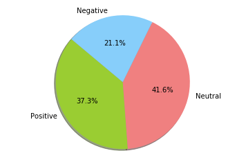

```python
# draw a pie chart for sentiment
labels = 'Positive', 'Neutral', 'Negative'
sizes = [192626, 214651, 109133]
colors = ['yellowgreen', 'lightcoral', 'lightskyblue']
plt.pie(sizes,labels=labels, colors=colors,autopct='%1.1f%%', shadow=True, startangle=140)
plt.axis('equal')
plt.show()
```

According to this pie chart, we can say that most people hold a neutral attitude towards this event. Over one third of the tweets have a positive sentiment, which are more than the negative ones.

**(2) How does the sentiments of posts change by time?**

```python
def positive(text):
    analysis=TextBlob(text)
    # set sentiment
    if analysis.sentiment.polarity > 0:
        return 1
    else:
        return 0
```

```python
data_location['positive']=0
data_location['positive']=data_location['Post'].map(positive)
```

```python
data_senti=data_location.set_index('Time').loc['2019-03-23 17:00:00':'2019-03-24 16:00:00']
data_senti['mean']=data_senti['positive'].mean()
```

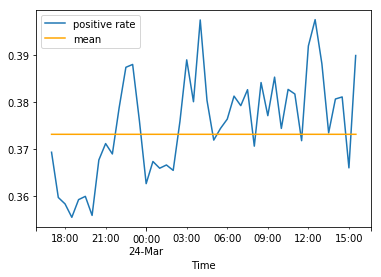

```python
data_senti['positive'].resample('30Min').mean().plot()
data_senti['mean'].plot(color='orange')
plt.legend(('positive rate','mean'))
```

**(3) How does the sentiments of posts change by location?**

To evaluate the overall sentiment of one state, we calculate the percentage of positive tweets in each state.

```python
# create a new dataframe, data_loc_senti, to show the overall sentiment in each state
data_loc_senti=data_location.groupby('Location')['positive'].mean().to_frame().reset_index()
data_loc_senti.columns=['STATE_ABBR','POSITIVE_PERC']
data_loc_senti.head()
```

|  | STATE_ABBR | POSITIVE_PERC |
| --- | --- | --- |
| 0 | KS | 0.333333 |
| 1 | LA | 0.435897 |
| 2 | WA | 1.000000 |
| 3 | AK | 0.000000 |
| 4 | AL | 0.000000 |

```python
usa=gpd.read_file('states_21basic')
usa1=usa[['STATE_ABBR','geometry']]
```

```python
colors = 10
cmap = 'GnBu'
figsize = (20, 10)
cols = ['STATE_NAME', 'STATE_ABBR', 'POSITIVE_PERC']
```

```python
loc_senti=usa.merge(data_loc_senti,on='STATE_ABBR')
loc_senti.head()
```

|  | STATE_NAME | DRAWSEQ | STATE_FIPS | SUB_REGION | STATE_ABBR | geometry | POSITIVE_PERC |
| --- | --- | --- | --- | --- | --- | --- | --- |
| 0 | Hawaii | 1 | 15 | Pacific | HI | (POLYGON ((-160.0738033454681 22.0041773479577... | 0.380392 |
| 1 | Washington | 2 | 53 | Pacific | WA | (POLYGON ((-122.4020153103835 48.2252163723779... | 0.387771 |
| 2 | Montana | 3 | 30 | Mountain | MT | POLYGON ((-111.4754253002074 44.70216236909688... | 0.387550 |
| 3 | Maine | 4 | 23 | New England | ME | (POLYGON ((-69.77727626137293 44.0741483685119... | 0.378151 |
| 4 | North Dakota | 5 | 38 | West North Central | ND | POLYGON ((-98.73043728833767 45.93827137024809... | 0.479290 |

```python
loc_senti['center']=loc_senti['geometry'].centroid
points_ls=loc_senti.copy()
points_ls.set_geometry("center", inplace = True)
labeles_ls=zip(points_ls['STATE_ABBR'],points_ls.geometry)
```

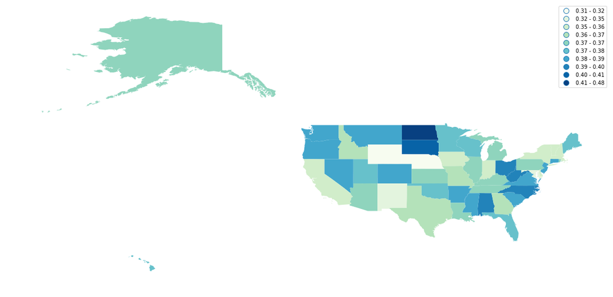

```python
ax = loc_senti.plot(column='POSITIVE_PERC', cmap=cmap, figsize=figsize, label='STATE_ABBR', scheme='fisher_jenks', k=colors,legend=True)
ax.set_axis_off()
fig = plt.gcf()
fig.set_size_inches(20,15)
for i, geo in labeles_ls:
    ax.annotate(s=i, xy=[geo.x, geo.y], color="black",fontsize=12)
ax.get_legend().set_bbox_to_anchor((1, 1))
```

[figure not shown]

We compared top 10 states with highest positive rate and those states voted for Trump in 2016.

```python
loc_senti.sort_values(['POSITIVE_PERC'],ascending=False).head(10).STATE_NAME
```

```
4       North Dakota
5       South Dakota
29     West Virginia
25              Ohio
42           Alabama
38    North Carolina
43       Mississippi
34          Virginia
45    South Carolina
46          Arkansas
Name: STATE_NAME, dtype: object
```

```python
# compare these ten states with all the states voting for Trump in 2016
vote=pd.read_html('https://en.wikipedia.org/wiki/2016_United_States_presidential_election',header=0)[40]
vote_for_trump=vote.iloc[1:,[0,6,7]]
vote_for_trump.columns=['STATE','%','VOTES']
vote_for_trump=vote_for_trump[vote_for_trump['VOTES']!='–']
vote_for_trump.drop([57,58],axis=0)
```

|  | STATE | % | VOTES |
| --- | --- | --- | --- |
| 1 | Alabama | 62.08% | 9 |
| 2 | Alaska | 51.28% | 3 |
| 3 | Arizona | 48.67% | 11 |
| 4 | Arkansas | 60.57% | 6 |
| 10 | Florida | 49.02% | 29 |
| 11 | Georgia | 50.77% | 16 |
| 13 | Idaho | 59.26% | 4 |
| 15 | Indiana | 56.82% | 11 |
| 16 | Iowa | 51.15% | 6 |
| 17 | Kansas | 56.65% | 6 |
| 18 | Kentucky | 62.52% | 8 |
| 19 | Louisiana | 58.09% | 8 |
| 22 | Maine, 2nd | 51.26% | 1 |
| 25 | Michigan | 47.50% | 16 |
| 27 | Mississippi | 57.94% | 6 |
| 28 | Missouri | 56.77% | 10 |
| 29 | Montana | 56.17% | 3 |
| 30 | Nebraska (at-lg) | 58.75% | 2 |
| 31 | Nebraska, 1st | 56.18% | 1 |
| 32 | Nebraska, 2nd | 47.16% | 1 |
| 33 | Nebraska, 3rd | 73.92% | 1 |
| 39 | North Carolina | 49.83% | 15 |
| 40 | North Dakota | 62.96% | 3 |
| 41 | Ohio | 51.69% | 18 |
| 42 | Oklahoma | 65.32% | 7 |
| 44 | Pennsylvania | 48.18% | 20 |
| 46 | South Carolina | 54.94% | 9 |
| 47 | South Dakota | 61.53% | 3 |
| 48 | Tennessee | 60.72% | 11 |
| 49 | Texas | 52.23% | 36 |
| 50 | Utah | 45.54% | 6 |
| 54 | West Virginia | 68.50% | 5 |
| 55 | Wisconsin | 47.22% | 10 |
| 56 | Wyoming | 67.40% | 3 |

We can find that 9 of 10 states with highest positive sentiment percentage voted for Trump Donald in 2016. It means that people in states supporting Trump tend to post positive tweets about the Mueller Report.